# Assignment 6

## Anne Tyvijärvi

### Part I

*Implement the analyses of Chapter 8 of MABS using the RATS data*

*“The rats data contains information collected from a nutrition study conducted in three groups of rats. The groups were put on different diets, and each animal’s body weight (grams) was recorded repeatedly (approximately) weekly, except in week seven when two recordings were taken) over a 9-week period.”*

I’ll start by reading in both data sets needed in this final data analysis.

The rats data contains information of rat weights over a period of time. Let’s transform Group and ID as factors.

```r
library(tidyverse)
library(lme4)
```

```r
library(ggplot2)

rats_new <- read.table("https://raw.githubusercontent.com/KimmoVehkalahti/MABS/master/Examples/data/rats.txt", header = TRUE)
BPRS_new <- read.table("https://raw.githubusercontent.com/KimmoVehkalahti/MABS/master/Examples/data/BPRS.txt", header = TRUE)

summary(rats_new)
```

```
##        ID            Group           WD1             WD8             WD15
##  Min.   : 1.00   Min.   :1.00   Min.   :225.0   Min.   :230.0   Min.   :230.0
##  1st Qu.: 4.75   1st Qu.:1.00   1st Qu.:252.5   1st Qu.:255.0   1st Qu.:255.0
##  Median : 8.50   Median :1.50   Median :340.0   Median :345.0   Median :347.5
##  Mean   : 8.50   Mean   :1.75   Mean   :365.9   Mean   :369.1   Mean   :372.5
##  3rd Qu.:12.25   3rd Qu.:2.25   3rd Qu.:480.0   3rd Qu.:476.2   3rd Qu.:486.2
##  Max.   :16.00   Max.   :3.00   Max.   :555.0   Max.   :560.0   Max.   :565.0
##       WD22            WD29            WD36            WD43
##  Min.   :232.0   Min.   :240.0   Min.   :240.0   Min.   :243.0
##  1st Qu.:267.2   1st Qu.:268.8   1st Qu.:267.2   1st Qu.:269.2
##  Median :351.5   Median :356.5   Median :360.0   Median :360.0
##  Mean   :379.2   Mean   :383.9   Mean   :387.0   Mean   :386.0
##  3rd Qu.:492.5   3rd Qu.:497.8   3rd Qu.:504.2   3rd Qu.:501.0
##  Max.   :580.0   Max.   :590.0   Max.   :597.0   Max.   :595.0
##       WD44            WD50            WD57            WD64
##  Min.   :244.0   Min.   :238.0   Min.   :247.0   Min.   :245.0
##  1st Qu.:270.0   1st Qu.:273.8   1st Qu.:273.8   1st Qu.:278.0
##  Median :362.0   Median :370.0   Median :373.5   Median :378.0
##  Mean   :388.3   Mean   :394.6   Mean   :398.6   Mean   :404.1
##  3rd Qu.:510.5   3rd Qu.:516.0   3rd Qu.:524.5   3rd Qu.:530.8
##  Max.   :595.0   Max.   :612.0   Max.   :618.0   Max.   :628.0
```

```r
str(rats_new)
```

```
## 'data.frame':    16 obs. of  13 variables:
##  $ ID   : int  1 2 3 4 5 6 7 8 9 10 ...
##  $ Group: int  1 1 1 1 1 1 1 1 2 2 ...
##  $ WD1  : int  240 225 245 260 255 260 275 245 410 405 ...
##  $ WD8  : int  250 230 250 255 260 265 275 255 415 420 ...
##  $ WD15 : int  255 230 250 255 255 270 260 260 425 430 ...
##  $ WD22 : int  260 232 255 265 270 275 270 268 428 440 ...
##  $ WD29 : int  262 240 262 265 270 275 273 270 438 448 ...
##  $ WD36 : int  258 240 265 268 273 277 274 265 443 460 ...
##  $ WD43 : int  266 243 267 270 274 278 276 265 442 458 ...
##  $ WD44 : int  266 244 267 272 273 278 271 267 446 464 ...
##  $ WD50 : int  265 238 264 274 276 284 282 273 456 475 ...
##  $ WD57 : int  272 247 268 273 278 279 281 274 468 484 ...
##  $ WD64 : int  278 245 269 275 280 281 284 278 478 496 ...
```

```r
rats_new$Group <- factor(rats_new$Group)
rats_new$ID <- factor(rats_new$ID)
colnames(rats_new)
```

```
##  [1] "ID"    "Group" "WD1"   "WD8"   "WD15"  "WD22"  "WD29"  "WD36"  "WD43"
## [10] "WD44"  "WD50"  "WD57"  "WD64"
```

Let’s transform the data into long form and also, extract the times value and create a new column containing the integer value of it.

Finally, let’s create a boxplot of the data. From this we can see that the three groups seem to be different.

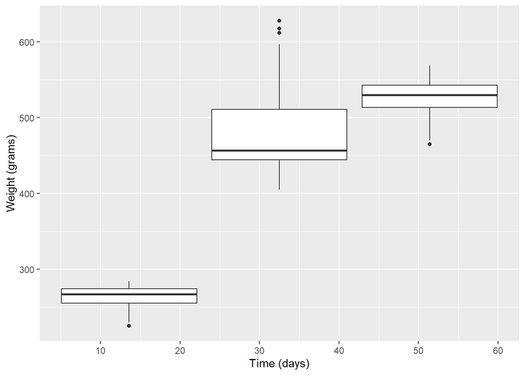

```r
# Transform the data to long form
ratsL <-  pivot_longer(rats_new, cols = -c(Group, ID),
                       names_to = "WD", values_to = "weight") %>%
          arrange(WD)

#Create a new column of the extracted times value
ratsL <-  ratsL %>%
            mutate(time = as.integer(substr(WD,3,4)))


#plot and group data by Groups
ggplot(ratsL, aes(x = time, y = weight, group = Group)) +
 geom_boxplot() +
 scale_x_continuous(name = "Time (days)", breaks = seq(0, 60, 10)) +
  scale_y_continuous(name = "Weight (grams)") +
  theme(legend.position = "top")
```

Let’s try standardizing the data (mean):

I’ll comment these out as it does not make any sense with this kind of data..

```r
#standardize
#ratsL <- ratsL %>%
 # group_by(time) %>%
  #mutate(stdweight = (weight - mean(weight))/sd(weight)) %>%
  #ungroup()

# Plot again
#ggplot(ratsL, aes(x = time, y = stdweight, group = Group)) +
 # geom_boxplot()
```

Next, let’s plot and visualize the data with standard error of the mean (SEM) (according to Groups). The SEM looks fine for all the groups. Group 1 has the smallest SEM, and maybe group 2 the biggest. Anyways, nothing alarming here.

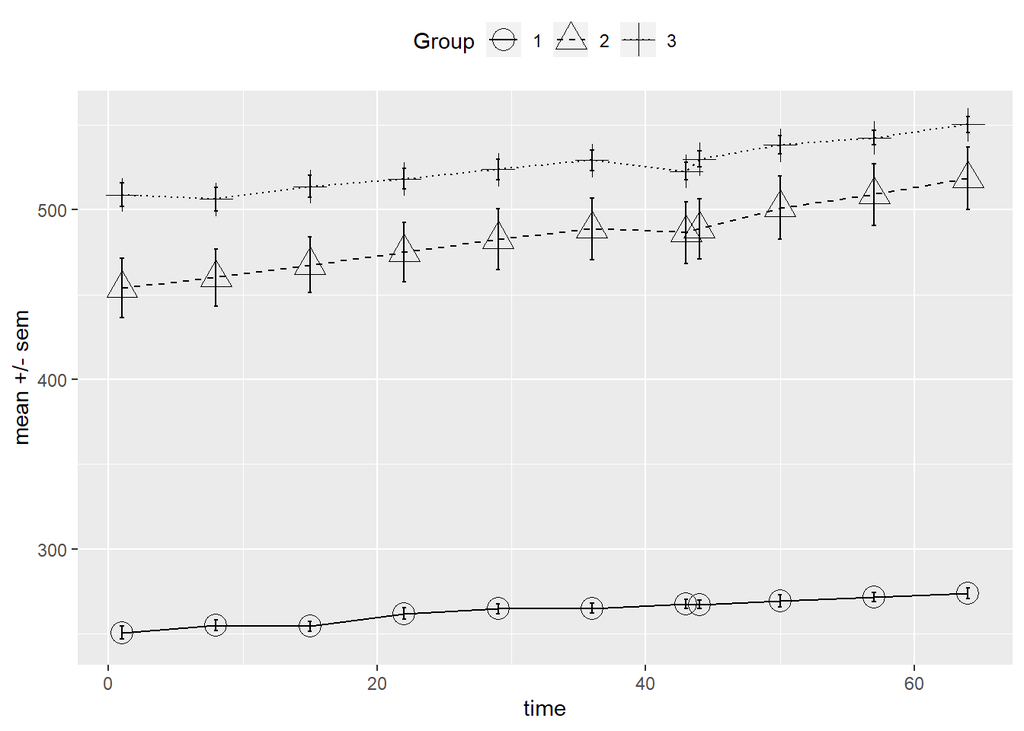

```r
#let's create columns for mean and sem
n <- 16
ratsLS <- ratsL %>%
  group_by(Group, time) %>%
  summarise(mean = mean(weight), se = sd(weight)/sqrt(n)) %>%
  ungroup()

# ..and plot the mean profiles
ggplot(ratsLS, aes(x = time, y = mean, linetype = Group, shape = Group)) +
  geom_line() +
  scale_linetype_manual(values = c(1,2,3)) +
  geom_point(size=5) +
  scale_shape_manual(values = c(1,2,3)) +
  geom_errorbar(aes(ymin=mean-se, ymax=mean+se, linetype="1"), width=0.3) +
  theme(legend.position = "top") +
  scale_y_continuous(name = "mean +/- sem")
```

Next let’s create a boxplot of the data, showing the mean and possible outliers in the data.

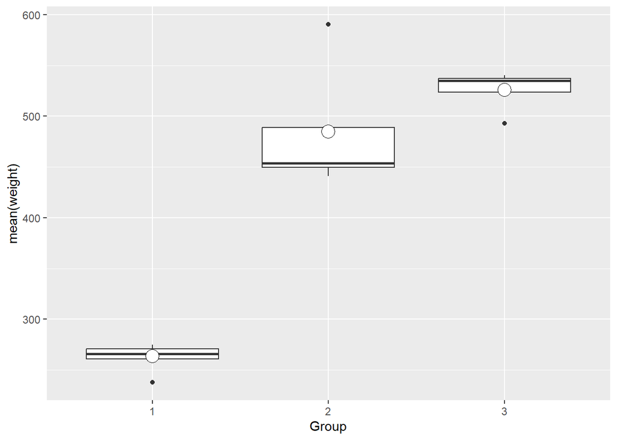

```r
ratsL8S <- ratsL %>%
  filter(time > 0) %>%
  group_by(Group, ID) %>%
  summarise( mean=mean(weight) ) %>%
  ungroup()

# Draw a boxplot of the mean versus treatment by Group
ggplot(ratsL8S, aes(x = Group, y = mean)) +
  geom_boxplot() +
  stat_summary(fun = "mean", geom = "point", shape=21, size=5, fill = "white") +
  scale_y_continuous(name = "mean(weight)")
```

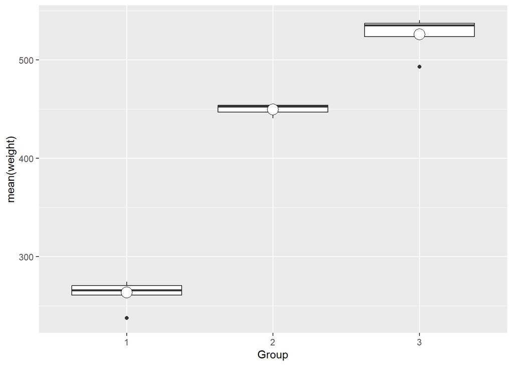

```r
#Let's try to filter some outliers (not sure what would be the best way to get rid of the third one)
ratsL8S1 <- ratsL8S %>%
  filter(mean < 550)
#ratsL8S2 <- ratsL8S1 %>%
  #filter(mean > 250)
#.. and plot again
ggplot(ratsL8S1, aes(x = Group, y = mean)) +
  geom_boxplot() +
  stat_summary(fun = "mean", geom = "point", shape=21, size=5, fill = "white") +
  scale_y_continuous(name = "mean(weight)")
```

I will not run a t-test here because it is for detecting differences between two groups (and we have three). Let’s just run a basic linear model with Anova. We can see that the means are significantly different between Groups (p < 0.001).

```r
lm1 <- lm(mean ~ Group, data = ratsL8S1)
summary(lm1)
```

```
##
## Call:
## lm(formula = mean ~ Group, data = ratsL8S1)
##
## Residuals:
##     Min      1Q  Median      3Q     Max
## -32.886  -3.080   3.273   9.250  14.386
##
## Coefficients:
##             Estimate Std. Error t value Pr(>|t|)
## (Intercept)  263.716      5.165   51.06 2.09e-15 ***
## Group2       185.739      9.890   18.78 2.90e-10 ***
## Group3       262.080      8.945   29.30 1.56e-12 ***
## ---
## Signif. codes:  0 '***' 0.001 '**' 0.01 '*' 0.05 '.' 0.1 ' ' 1
##
## Residual standard error: 14.61 on 12 degrees of freedom
## Multiple R-squared:  0.9877, Adjusted R-squared:  0.9857
## F-statistic: 483.6 on 2 and 12 DF,  p-value: 3.387e-12
```

```r
anova(lm1)
```

```
## Analysis of Variance Table
##
## Response: mean
##           Df Sum Sq Mean Sq F value    Pr(>F)
## Group      2 206390  103195   483.6 3.387e-12 ***
## Residuals 12   2561     213
## ---
## Signif. codes:  0 '***' 0.001 '**' 0.01 '*' 0.05 '.' 0.1 ' ' 1
```